# Fake news detection using PyTorch

### Develop and train a model that can accurately detect if an article is fake news based on the content.

**Data:** The University of Victoria's ISOT lab put together a fake news dataset that is broken into two distinct files:

1. `Fake.csv`
2. `True.csv`

Each file carries articles of a specific flag (self-explanatorily as *fake news* or *true news*)

**Question:** Can we build a neural network, trained on the ISOT data, that can accurately detect if any article is true or fake? YES/NO

**Goal:** Develop and train a model that can accurately detect if an article is fake news based on the content.

```python
!pip install sagemaker==1.72.0;
```

```python
import pandas as pd
import numpy as np
import matplotlib.pyplot as plt

from sklearn.model_selection import train_test_split

%config InlineBackend.figure_format='retina'
```

### Reading in data

```python
###reading in only text data
###files also have additional fields such as date, that will not be used in the analysis

fake = pd.DataFrame((pd.read_csv('Fake.csv', delimiter = ';', warn_bad_lines=False))["text"])
true = pd.DataFrame((pd.read_csv('True_2.csv', delimiter = ';', warn_bad_lines=False))["text"]);
```

### Examining samples of the data.

```python
fake.head()
```

|  | text |
| --- | --- |
| 0 | House Intelligence Committee Chairman Devin Nu... |
| 1 | On Friday, it was revealed that former Milwauk... |
| 2 | On Christmas day, Donald Trump announced that ... |
| 3 | Pope Francis used his annual Christmas Day mes... |
| 4 | The number of cases of cops brutalizing and ki... |

```python
true.head()
```

|  | text |
| --- | --- |
| 0 | The head of a conservative Republican faction ... |
| 1 | Transgender people will be allowed for the fir... |
| 2 | The special counsel investigation of links bet... |
| 3 | Trump campaign adviser George Papadopoulos tol... |
| 4 | SEATTLE/President Donald Trump called on the U... |

## Classifying, concatenating, and shuffling

Now that the data is read in and appears okay. However it is still split into two distinct files. Whereas they should be as one.

1. Merge the two data sets.
2. Add classification labels to both dataframes (Fake is 1, True is 0)
3. Concatenate the dataframes
4. Shuffle the data to avoid biasing while splitting data later. This is especially important since stratifying is not readily doable with textual data.

```python
def prep_df(df_fake, df_true):
    '''
    Takes two input dataframes for fake and true articles
    Assigns a boolean class to each (a fake article is positive and gets value 1)
    Then concatenates into one dataframe, and shuffles at random
    '''

    df_fake["isFake"] = 1
    df_true["isFake"] = 0

    df_out = (pd
              .concat((df_fake.dropna(axis = 0, how = 'any'), df_true.dropna(axis = 0, how = 'any')))
              .sample(frac = 1, replace = False, random_state = 200))

    '''Note: pd.sample with frac = 1 and replace = False is effectively a random shuffle'''

    return df_out
```

```python
df_shuffled = prep_df(fake, true)
```

```python
df_shuffled["isFake"].value_counts()
```

```
1    23285
0    17826
Name: isFake, dtype: int64
```

```python
df_shuffled.head()
```

|  | text | isFake |
| --- | --- | --- |
| 13440 | Wikileaks has opened our eyes to so much corru... | 1 |
| 15379 | Judge William H. Orrick, III joins Obama in hi... | 1 |
| 8121 | Within hours of the death of Supreme Court Jus... | 1 |
| 4425 | Just hours after Trump told millions of voters... | 1 |
| 2764 | WINNIPEG, Manitoba Former U.S. President Jimmy... | 0 |

```python
data, labels = np.array(df_shuffled["text"]), np.array(df_shuffled["isFake"])
X_train, X_test, y_train, y_test = train_test_split(data, labels, test_size=0.25, random_state = 100)
```

## Example fake article

I am reading in a sample fake article to show example text. That way I can track and see how it is later processed and input into the PyTorch model.

**I am holding all random states and seeds in the remainder of the notebook constant for reproducibility and consistency.**

```python
print(X_train[120], y_train[120])
```

```
Freedom is under attack across the globe. Radical Muslims are committing horrendous acts of violence against innocent people around the world. Meanwhile, the Left demands we don t identify the faith of the terrorists, for fear of offending them. It s time to fight back America. The Netherlands, Fran…
```

Approximately very similar sizes, which is good. Can use accuracy as a measure of model performance. But will still need to check for any false positives (since articles skew slightly towards fake).

```python
import pickle
import os

from collections import Counter

import sagemaker
from sagemaker.pytorch import PyTorch

import torch
import torch.utils.data
```

## A sequence of functions for formatting text, removing stop words, and stemming

Before proceeding, we need to make sure that the text above (which is easily readable by a human), needs to become machine-readable. That means breaking up a sentence into words, and identifying words as indices.

I will eventually get into indexing words, but for now, the following pre-processing is done:

1. First, remove any HTML tags (there aren't any in the text, but this is to future-proof any implementation).
2. Turn all letters into lowercase.
3. Split strings into lists of words.
4. Remove all stop words from the lists.
5. Use `PortStemmer()` to stem words to their shortest distinct form.

```python
def format_clean(article):
    from bs4 import BeautifulSoup
    import re

    '''
    Removes HTML tags and changes to lower case.
    Then splits text into a list of individual words.
    '''

    text = BeautifulSoup(article, "html.parser").get_text()
    text = re.sub(r"[^a-zA-Z0-9]", " ", text.lower())

    return text.split()
```

```python
def remove_stopwords(text):
    import nltk
    from nltk.corpus import stopwords

    '''
    Remove stop words (e.g. the, a, at, an)
    Return list of words without stop words
    '''

    nltk.download("stopwords", quiet = True)

    words      = []
    for word in text:
        if word not in stopwords.words("english"):
            words.append(word)

    return words
```

```python
def stem_words(text):
    from nltk.stem.porter import PorterStemmer

    '''
    Stem each word to its least ambiguous form (e.g. president --> presid)
    To account for tenses and so on.
    Returns a list of stemmed words
    '''

    stemmer = PorterStemmer()
    words   = []
    for word in text:
        words.append(stemmer.stem(word))

    return words
```

```python
#adapting the stemming algorithm used in the first project in this course.

def article_to_words_clean(article):

    text         = format_clean(article)
    text_no_stop = remove_stopwords(text)
    text_stemmed = stem_words(text_no_stop)

    return text_stemmed
```

## The upcoming functions will apply the preceding sequence of functions and create a pickle file for easier loading later.

The following function will process the above functions en masse for all articles in the data set. It will then save the result as an output `.pkl` file.

That pickle file is especially important **since each run can take well upwards of an hour.**

If a pickle file already exists, it will simply read it in, saving substantial compute (and actual) time.

```python
def pickle_dump_words(X_train, X_test, y_train, y_test, cache_dir, cache_file):
    '''
    Performs the word cleaning and stemming function on all the articles in the dataset
    Places each article into a list of articles
    Then outputs a dictionary of the cleaned lists and the corresponding labels
    Dumps into a pickle file for easy loading later.
    '''

    words_train = [article_to_words_clean(article) for article in X_train]
    words_test  = [article_to_words_clean(article) for article in X_test]

    cache_data  = dict(words_train = words_train, words_test = words_test,
                       labels_train = y_train, labels_test = y_test)

    file        = open(os.path.join(cache_dir, cache_file), 'wb')


    pickle.dump(cache_data, file)
    print('File created!')

    return cache_data
```

```python
def create_cache_file(cache_dir, cache_file):
    '''
    Looks for a previously created pickle file to load
    If none found, pass None
    Overrides errors for no file found using a try/except
    '''
    try:
        '''First look for previously loaded in cache files'''
        file       = open(os.path.join(cache_dir, cache_file), 'rb')
        cache_data = pickle.load(file)
        print("Read data from cache file:", file)

    except:
        '''If it's not found, override the error using a try/except and proceed to creating file'''
        print("File not found, producing file.")
        cache_data = None
        pass

    return cache_data
```

```python
#adapted from the pickling algorithm from the first Udacity ML Engineer project
def cache_data_to_words(X_train, X_test, y_train, y_test, cache_dir='cache', cache_file="cached_data.pkl"):

    cache_data = create_cache_file(cache_dir, cache_file)

    if cache_data is None:
        '''
        File was not created in previous step, therefore begin building the arrays
        Using the article_to_words_clean functionality above
        '''
        cache_data = pickle_dump_words(X_train, X_test, y_train, y_test, cache_dir, cache_file)


    words_train, words_test   = (cache_data['words_train'], cache_data['words_test'])
    labels_train, labels_test = (cache_data['labels_train'], cache_data['labels_test'])

    return words_train, words_test, labels_train, labels_test
```

```python
cache_dir = 'cache'
os.makedirs(cache_dir, exist_ok=True)
```

```python
X_train, X_test, y_train, y_test = cache_data_to_words(X_train, X_test, y_train, y_test)
```

```
Read data from cache file: <_io.BufferedReader name='cache/cached_data.pkl'>
```

## Same example article from above now processed

All formatting has been removed. All stop words as well. The main words are left behind and stemmed to the bare minimum recognizable form.

This will be further processed into a list of indices, where each index will correspond to a specific word.

```python
print(X_train[120], y_train[120])
```

```
['freedom', 'attack', 'across', 'globe', 'radic', 'muslim', 'commit', 'horrend', 'act', 'violenc', 'innoc', 'peopl', 'around', 'world', 'meanwhil', 'left', 'demand', 'identifi', 'faith', 'terrorist', 'fear', 'offend', 'time', 'fight', 'back', 'america', 'netherland', 'franc', 'uk', 'futur', 'morocca…
```

## Word dictionary

**Now for the first step in indexing words...**

The following function will now sift through all the data, find the $N-2$ most common words, and order them by frequency.

$N = 5000$ by default.

The reason it looks for $N-2$ words and not $N$ is because it saves 2 extra indices: one for "no word" (index `0`) and one for infrequent words (`1`). The most frequent word gets the next index (`2`), and so on.

The function also separately outputs the number of times each word appears. This is not for the model. This is purely for analytical purposes; so I can visualize which words are most common for true & fake data.

```python
def build_and_save_dict(data, vocab_size = 5000):
    '''
    Creating a dictionary of words based on frequency of appearance
    The function also allows for no word labels (index = 0) and 'infrequent' words (index = 1)
    The no word and infrequent labels are assigned in a later function

    INPUT:
    * data: a list of sentences
    * vocab_size: the desired output size of the dictionary. Function will find the most common
                  (vocab_size - 2) words. The other 2 indices are for no words or infrequent words.

    RETURNS:
    * word_dict: a dictionary of most common words ordered from most to least frequent. The indices
                 correspond to the word frequency rank, not the actual frequency of appearance.
                 THIS IS WHAT IS USED AS INPUT TO THE MODEL.
    * word_count: a dictionary of words with the frequency of appearance. This is NOT used by the model,
                  but is simply collected for analytical purposes.
    '''

    word_count = {}
    for sentence in data:
        for word in sentence:
            if word in word_count:
                word_count[word] += 1
            else:
                word_count[word] = 1

    sorted_words = sorted(word_count, key = word_count.get, reverse = True)

    word_dict = {}
    for idx, word in enumerate(sorted_words[:vocab_size - 2]):
        word_dict[word] = idx + 2

    with open(os.path.join('pytorch_files/word_dict.pkl'), "wb") as f:
        '''
        No need to check if old file exists. Process is fast enough that can just overwrite every time.
        Also overcomes added complexities if need to later change vocab_sizen in a given run
        '''
        pickle.dump(word_dict, f)

    return word_dict, word_count
```

## Building word dictionaries separately of true and fake article words

This is for analytical and visualization purposes only!!!

Does not impact the model fitting later on at all.

```python
X_train_true, X_train_fake = [], []

for idx, x in enumerate(X_train):
    if y_train[idx] == 1:
        X_train_fake.append(x)
    else:
        X_train_true.append(x)
```

```python
word_dict_true, word_count_true = build_and_save_dict(X_train_true, vocab_size = 5000)
word_dict_fake, word_count_fake = build_and_save_dict(X_train_fake, vocab_size = 5000)
```

```python
most_common_words_true = sorted(word_dict_true, key = word_dict_true.get)[0:20]
most_common_words_fake = sorted(word_dict_fake, key = word_dict_fake.get)[0:20]
```

```python
most_common_words_true_freq = []
most_common_words_fake_freq = []

for word in most_common_words_true:
    most_common_words_true_freq.append(word_count_true[word])

for word in most_common_words_fake:
    most_common_words_fake_freq.append(word_count_fake[word])
```

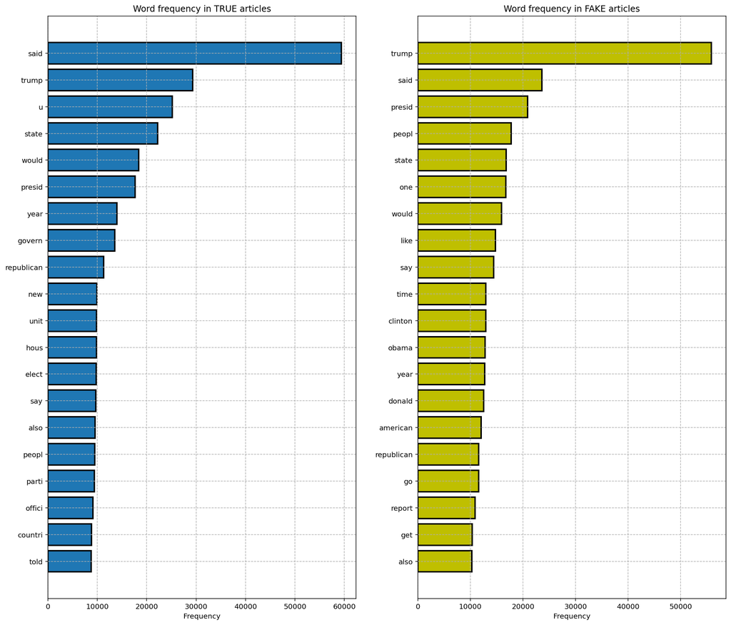

```python
%config InlineBackend.figure_format='retina'

fig = plt.figure(figsize = (17,15))
ax1 = fig.add_subplot(121)
ax2 = fig.add_subplot(122)


y_pos = np.arange(len(most_common_words_true))

ax1.barh(y_pos, most_common_words_true_freq, edgecolor = 'k', linewidth = 2.0)
ax1.set_yticks(y_pos)
ax1.set_yticklabels(most_common_words_true)
ax1.set_ylim(ax1.get_ylim()[::-1])
ax1.set_title('Word frequency in TRUE articles')
ax1.grid(linestyle = '--')
ax1.set_xlabel('Frequency')


'''--------------------------------------------'''


ax2.barh(y_pos, most_common_words_fake_freq, color = 'y', edgecolor = 'k', linewidth = 2.0)
ax2.set_yticks(y_pos)
ax2.set_yticklabels(most_common_words_fake)
ax2.set_ylim(ax2.get_ylim()[::-1])
ax2.set_title('Word frequency in FAKE articles')
ax2.grid(linestyle = '--')
ax2.set_xlabel('Frequency')

plt.savefig('word_frequency_barcharts.pdf');
```

### Sources of bias

Note that this notebook is a second iteration, where the word "Reuters" was removed from all article texts. The previous iteration with the word "Reuters" was only about 50% accurate with external article sources. And it was heavily biased by just that one word.

Now looking at the above figure...

Even now there are some biases. While the collection of words between True and Fake articles seems on the whole decently homogenous, some things stand out. For example, `clinton` and `obama` are in the 20 most common words used in Fake articles.

This is a significant source of bias in the original data set. Since any legitimately true article containing either word can now bias heavily towards a false positive (Fake label).

```python
###clearing memory, since data is rather large
fake, true, df, df_shuffled, data, labels, most_common_words_true, most_common_words_fake = None, None, None, None, None, None, None, None
```

# Building overall `word_dict` for use in model

Based on all the articles, fake or real.

```python
word_dict, word_count = build_and_save_dict(X_train, vocab_size = 5000)
```

# And now to convert all words into indices

The following function will:

1. Take the full data set.
2. Read in each sentence (already stemmed and processed).
3. Assign each word an index based on the above produced `word_dict`
4. Pad/truncate each sentence to keep them all the same length (avoid biasing model by length).
5. Output a machine-readable form of the data.

```python
def verbose_to_indices_all(word_dict, data, pad = 500):
    ###adapted from first project

    '''
    Takes in all the verbose reviews in the training data and returns reviews comprised of of indices,
    based on word locations in word_dict.
    Assign the first two indices (0,1) to no words, or infrequent words, respectively.
    Starts by assigning noword to all word locations, then add words one at a time

    Input arguments:
    * word_dict: a dictionary object with words ordered by frequency, from most to least frequent
    * data: a list of sentences, NOT an array or other type of object
    * pad: the maximum allowed length of a sentence (default: 500). If a sentence is shorter than 500 words
           it will pad it to 500. A sentence longer than 500 words will be truncated to 500.

    Returns:
    A numpy array of the the processed data in indices, concatenated with an array of the sentence lengths.
    '''
    noword = 0
    infreq = 1

    data_out = []
    data_len = []

    for sentence in data:

        sentence_pad = [noword] * pad

        for ind, word in enumerate(sentence[:pad]):
            if word in word_dict:
                ###if word is in the dictionary, assign its corresponding index
                sentence_pad[ind] = word_dict[word]
            else:
                ###else just fill it with the infrequent index (1)
                sentence_pad[ind] = infreq

        data_out.append(sentence_pad)
        data_len.append(min(len(sentence), pad))

    return np.array(data_out), np.array(data_len)
```

```python
train_X_pad, train_X_len = verbose_to_indices_all(word_dict, X_train)
test_X_pad,   test_X_len = verbose_to_indices_all(word_dict, X_test)
```

Just some print statements to ensure all worked as intended.

```python
print(len(train_X_pad[100]))
print(train_X_len[100])
```

```
500
3
```

```python
data_dir = 'pytorch_files'
os.makedirs(data_dir, exist_ok=True)
```

```python
pd.concat([pd.DataFrame(y_train), pd.DataFrame(train_X_len), pd.DataFrame(train_X_pad)], axis=1) \
        .to_csv(os.path.join(data_dir, 'train.csv'), header=False, index=False)
```

```python
sagemaker_session = sagemaker.Session()

bucket = sagemaker_session.default_bucket()
prefix = 'sagemaker/fake_news_lstm_rnn'

role = sagemaker.get_execution_role()
```

**Make sure input data is uploaded to an S3 bucket ready for training.**

```python
input_data = sagemaker_session.upload_data(path=data_dir, bucket=bucket, key_prefix=prefix)
```

# Training and inference

Now this is the fun part!

The following is a training and inference exercise. First, I will be testing a single-layer model versus a multi-layer model.

Both models have the same embedding elements (`16`) and hidden elements (`64`). But the multi-layer model has 3 layers with a 10% chance of dropout. The choice of 3 was made, since any more (4+) resulted in an overly lengthy computational time.

## Single-layer model first

```python
from sagemaker.pytorch import PyTorch

estimator_single = PyTorch(entry_point="train.py",
                    source_dir="pytorch_files",
                    role=role,
                    framework_version='0.4.0',
                    train_instance_count=1,
                    train_instance_type='ml.p2.xlarge',
                    hyperparameters={
                        'epochs': 20,
                        'hidden_dim': 64,
                        'embedding_dim': 16,
                        'num_layers':1,
                        'dropout':0
                    })
```

```python
estimator_single.fit({'training': input_data})
```

```
'create_image_uri' will be deprecated in favor of 'ImageURIProvider' class in SageMaker Python SDK v2.
's3_input' class will be renamed to 'TrainingInput' in SageMaker Python SDK v2.
'create_image_uri' will be deprecated in favor of 'ImageURIProvider' class in SageMaker Python SDK v2.
```

[output not shown]

[output cut: 97 more lines]

```
Epoch: 12, BCELoss: 0.21521971020542208
Epoch: 13, BCELoss: 0.18674945562589365
Epoch: 14, BCELoss: 0.15447608870072443
Epoch: 15, BCELoss: 0.1334925486904676
Epoch: 16, BCELoss: 0.12539568665574807
Epoch: 17, BCELoss: 0.11633317917585373
Epoch: 18, BCELoss: 0.11088466045797848
Epoch: 19, BCELoss: 0.10665523505113164
Epoch: 20, BCELoss: 0.1475385079374079
2021-05-31 19:39:15,444 sagemaker-containers INFO     Reporting training SUCCESS

2021-05-31 19:39:24 Uploading - Uploading generated training model
2021-05-31 19:39:24 Completed - Training job completed
Training seconds: 245
Billable seconds: 245
```

```python
predictor_single = estimator_single.deploy(initial_instance_count = 1, instance_type='ml.c4.xlarge')
```

```
Parameter image will be renamed to image_uri in SageMaker Python SDK v2.
'create_image_uri' will be deprecated in favor of 'ImageURIProvider' class in SageMaker Python SDK v2.
```

```
-----------------!
```

## Multi-layer model next

```python
from sagemaker.pytorch import PyTorch

estimator_multi = PyTorch(entry_point="train.py",
                    source_dir="pytorch_files",
                    role=role,
                    framework_version='0.4.0',
                    train_instance_count=1,
                    train_instance_type='ml.p2.xlarge',
                    hyperparameters={
                        'epochs': 20,
                        'hidden_dim': 64,
                        'embedding_dim': 16,
                        'num_layers':3,
                        'dropout':0.1
                    })
```

```python
estimator_multi.fit({'training': input_data})
```

```
'create_image_uri' will be deprecated in favor of 'ImageURIProvider' class in SageMaker Python SDK v2.
's3_input' class will be renamed to 'TrainingInput' in SageMaker Python SDK v2.
'create_image_uri' will be deprecated in favor of 'ImageURIProvider' class in SageMaker Python SDK v2.
```

[output not shown]

[output cut: 97 more lines]

```
Epoch: 12, BCELoss: 0.11588615630982352
Epoch: 13, BCELoss: 0.09249182912658473
Epoch: 14, BCELoss: 0.0990784055873996
Epoch: 15, BCELoss: 0.08763200166772624
Epoch: 16, BCELoss: 0.0799549424135294
Epoch: 17, BCELoss: 0.0805974042073625
Epoch: 18, BCELoss: 0.08180122541599587
Epoch: 19, BCELoss: 0.06359718065159242
Epoch: 20, BCELoss: 0.05946117283806938
2021-05-31 20:00:49,828 sagemaker-containers INFO     Reporting training SUCCESS

2021-05-31 20:00:58 Uploading - Uploading generated training model
2021-05-31 20:00:58 Completed - Training job completed
Training seconds: 560
Billable seconds: 560
```

```python
predictor_multi = estimator_multi.deploy(initial_instance_count = 1, instance_type='ml.c4.xlarge')
```

```
Parameter image will be renamed to image_uri in SageMaker Python SDK v2.
'create_image_uri' will be deprecated in favor of 'ImageURIProvider' class in SageMaker Python SDK v2.
```

```
-----------------!
```

## Visually examine BCE loss for both single- and multi-layer models.

Let's take a short break to take a look at how the BCE loss progressed with epochs for each model.

```python
single_loss = [0.6299339747819744,
                0.513636046745738,
                0.4653340690448636,
                0.42154308371856564,
                0.3840792325676465,
                0.35087861584835367,
                0.31389272188554046,
                0.2537780699671292,
                0.21872876999808138,
                0.19235924203864863,
                0.17113909296324994,
                0.21521971020542208,
                0.18674945562589365,
                0.15447608870072443,
                0.1334925486904676,
                0.12539568665574807,
                0.11633317917585373,
                0.11088466045797848,
                0.10665523505113164,
                0.1475385079374079]

multi_loss = [0.5980247459450706,
                0.41426852687460475,
                0.3066226116946486,
                0.2711039532403477,
                0.2021378989590973,
                0.17691116376978452,
                0.1476357909011059,
                0.21641988307237625,
                0.15029222115141447,
                0.12168765080268265,
                0.13065138886697958,
                0.11588615630982352,
                0.09249182912658473,
                0.0990784055873996,
                0.08763200166772624,
                0.0799549424135294,
                0.0805974042073625,
                0.08180122541599587,
                0.06359718065159242,
                0.05946117283806938]

epochs = np.linspace(1,20,20)
```

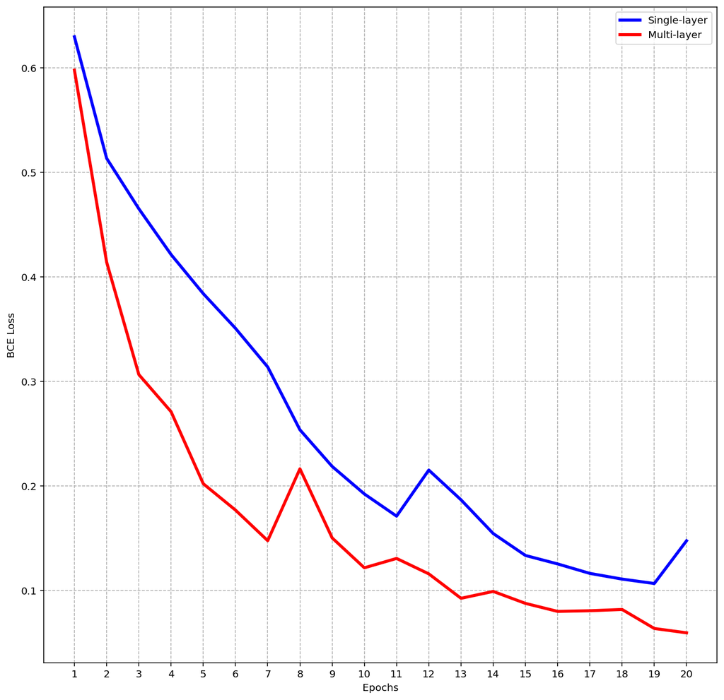

```python
fig = plt.figure(figsize = (12,12))
ax1 = fig.add_subplot(111)
ax1.grid(linestyle = '--')

ax1.plot(epochs, single_loss, label = 'Single-layer', color = 'b', linewidth = 3)
ax1.plot(epochs, multi_loss, label = 'Multi-layer', color = 'r', linewidth = 3)

ax1.set_xlabel('Epochs')
ax1.set_ylabel('BCE Loss')

ax1.set_xticks(epochs)

plt.legend()
plt.savefig('bceloss_multi_single.pdf');
```

**The multi-layer model sees a far steeper far in BCE loss in the first few epochs.**

It continues to stay lower than the single-layer model all throughout all 20 epochs of training.

Now back to inference...

## Produce a concatenated Pandas Dataframe with test data for inference

```python
test_X = pd.concat([pd.DataFrame(test_X_len), pd.DataFrame(test_X_pad)], axis=1)
```

```python
def predict(data, predictor, rows=512):
    split_array = np.array_split(data, int(data.shape[0] / float(rows) + 1))
    predictions = np.array([])
    for array in split_array:
        predictions = np.append(predictions, predictor.predict(array))

    return predictions
```

```python
predictions = predict(test_X.values, predictor_single)
predictions = [round(num) for num in predictions]
```

```python
from sklearn.metrics import accuracy_score, precision_score, recall_score
print(accuracy_score(y_test, predictions),
      precision_score(y_test, predictions),
      recall_score(y_test, predictions)
     )
```

```
0.9432769021210352 0.9582817747922927 0.9398404993065187
```

```python
print(y_test[0:10])
```

```
[1 0 1 1 1 1 0 1 1 0]
```

```python
print(predictions[0:10])
```

```
[1, 0, 1, 1, 1, 1, 0, 1, 1, 0]
```

```python
predictions = predict(test_X.values, predictor_multi)
predictions = [round(num) for num in predictions]

print(accuracy_score(y_test, predictions),
      precision_score(y_test, predictions),
      recall_score(y_test, predictions)
     )
```

```
0.9732438217552053 0.9752552344696315 0.9771151178918169
```

# Metrics on test data

## **Single-layer model**

Accuracy = $94.3\%$  
Precision = $95.8\%$  
Recall = $93.9\%$

Both models perform well (>$90\%$). However, the multi-layer model performs marginally better than the single-layer, on the test data.

The single-layer model has a slight but measurable skew to false negatives (falsely classifying a fake article as true). This is evident in both the higher-than-accuracy precision, and lower recall.

## External data sources

The multi-layer model has an advantage on the test data. But this may be due to overfitting!

Let's proceed with some **external article sources** to see how each model performs on new data.

```python
def verbose_to_indices_single(word_dict, sentence, pad=500):
    '''
    This is similar to teh verbose_to_indices_all() function above, but designed for one single sentence
    That way it can be used in a for loop on a predictor object to test on external data sources
    '''
    noword = 0
    infreq = 1

    data_out = []
    data_len = []

    sentence_pad = [noword] * pad

    for ind, word in enumerate(sentence[:pad]):
        if word in word_dict:
            ###if word is in the dictionary, assign its corresponding index
            sentence_pad[ind] = word_dict[word]
        else:
            ###else just fill it with the infrequent index (1)
            sentence_pad[ind] = infreq

    data_out.append(sentence_pad)
    data_len.append(min(len(sentence), pad))

    return np.array(data_out), np.array(data_len)
```

The following sources were picked for `True` articles:

1. New York Times
2. CNN
3. BBC

**No op-eds were chosen**. Only articles that state events and happenings, in a reasonably factual way. Some embellishment in words happens of course. But so long as the content seems logically and falsifiably true, it was okay.

Some articles involving Obama were deliberately included. This is since the word `obama` featured significantly in the fake dataset.

For fake articles:

1. The Onion

The Onion was chosen as the sole source of fake news. That way I would not have to insert my own subjective bias. The Onion is satirical, and deliberately false. Therefore, all articles from the Onion are `Fake`.

```python
sample_articles = ['''Several states are turning away Covid vaccine doses from their federal government allocations, as the daily average of coronavirus vaccine doses administered across the United States has fallen below two million for the first time since early March. Experts say the states’ smaller requests reflect a steep drop in vaccine demand in the United States. Wisconsin officials have asked for just 8 percent of the 162,680 doses the federal government had set aside for the state next week, according to The Associated Press. In Iowa, officials asked for just 29 percent of the state’s allocated doses. And in Illinois, the state is planning to request just 9 percent of its allotted doses for everywhere, except for Chicago, for next week, The A.P. reported.''',
                  '''BELOIT, WI—Gasping sharply and demanding their son to report to his room this instant, conservative parents Justine and Stewart Taylor asked their son Thursday if he’d care to explain why there was a vaccine card hidden in his underwear drawer. “So, is there anything in particular that you’d like to tell us—or did you think we were stupid and just wouldn’t find out?” said Stewart, holding up his child’s inoculation records, squinting, and whispering, “Don’t lie to me, son,” as his wife sobbed quietly in the background. “Sixteen years of clothing you, feeding you, and loving you with all our hearts, and this is how you repay us? Just look at what you’ve done to your mother! She didn’t raise you to go off into some tent full of miscreants God knows where and inject this kind of terrible stuff into your body. I thought we taught you right, but you know, you’re just one more dose of Moderna or Pfizer from losing your mind, or worse, ending up in a ditch somewhere, dead.” At press time, the Taylors had reportedly thrown their son out onto the street with nothing but his masks and hand sanitizer after rolling up his sleeve to find a bandage.''',
                  '''The remains of a Chinese rocket that was hurtling back towards Earth have crashed into the Indian Ocean, the country's space agency says.
                    The bulk of the rocket was destroyed as it re-entered the atmosphere, but state media reported that debris landed just west of the Maldives on Sunday.
                    There have been days of speculation over where the rocket might land, and US officials and other experts warned its return risked potential casualties.
                    But China insisted the risk was low.
                    The Long March-5b vehicle re-entered the atmosphere at 10:24 Beijing time (02:24 GMT) on Sunday, state media reported, citing the Chinese Manned Space Engineering office. There were no reports of injuries or damage.''',
                  '''PHILADELPHIA—Admitting that he was unsure how to harness his new abilities, Wells Fargo Center DJ Levi Ellington was overwhelmed Thursday by his godlike power after getting fans to snap along to The Addams Family theme song on command. “They clap when I say clap, they stomp when I say stomp, what won’t they do?” said Ellington, whose hands shivered with nervous uncertainly while he weighed which song to play next. “I asked them to chant ‘defense,’ and they did exactly as I decreed. I could play anything, even the ‘Hokie Pokey,’ and they’d be eating out of the palm of my hand. With one simple shift of this slider, I could get them out of their seats and doing the ‘Y.M.C.A.’ dance in no time.” At press time, Ellington was rapidly spiraling after Sixers fans ignored his medley of Montell Jordan hits.''',
                  '''Apple has hired a new vice president of worldwide corporate communications. Stella Low, former communications chief at networking giant Cisco, will take on the role, which has been unfilled since late 2019.
                    A tech industry veteran, Low has done stints at Unisys and Dell, where she served as senior vice president of communications. She'll report directly to Apple CEO Tim Cook.''',
                  '''Bo, the Portuguese water dog who became the first presidential pet in the Obama White House, romping in the halls of power, died on Saturday.
                    Bo, who was 12, had cancer, Michelle Obama said on Instagram. President Barack Obama said the family had lost “a true friend and loyal companion.”
                    “For more than a decade, Bo was a constant, gentle presence in our lives — happy to see us on our good days, our bad days, and everyday in between,” Mr. Obama wrote on Twitter.''',
                  '''At least two European airlines have been refused permission to fly to Moscow by Russian authorities after the carriers requested to fly an alternative route bypassing Belarusian airspace.
                    Russia's move, underlining Moscow's support for Belarusian President Alexander Lukashenko's regime, comes as the European Union mulls fresh sanctions against Belarus following what leaders have described as the state-sanctioned hijacking of a passenger flight over Belarus last Sunday.''',
                  '''The number of Covid-19 patients being treated in Dutch hospitals fell by seven percent in a day, the LCPS said on Thursday afternoon. It was the tenth straight decrease, which brought the total down to 1,512, the lowest since October 14.
                    The total was 20 percent lower than a week ago. Should that trend continue, there will be close to 1,200 patients in care in seven days.
                    Thursday's tally included 971 patients in non-acute care wards, a net decrease of 88, bringing the figure below a thousand for the first time since early October. The intensive care total of 541 was similar to figures seen in early March after a single-day net decrease of 18 patients.''',
                  '''MINNEAPOLIS—Following a year of upheaval that saw the country undergo a massive reckoning regarding state-sponsored violence, Minneapolis honored victims of police brutality Thursday by dedicating a fleet of armored vehicles to George Floyd. “These state-of-the-art military-style trucks equipped with power turrets and tear-gas deployment nozzles serve as a fitting tribute to a man whose life was cut tragically short,” said Mayor Jacob Frey during the dedication ceremony in which the six $750,000 armored vehicles adorned with Floyd’s image were paraded through the city’s downtown area. “We hope that all residents will think of George Floyd whenever they feel the ground quaking as these eight-ton vehicles roll by and reflect on how much we’ve accomplished since his untimely death, and how much further we still have to go. I’m thankful to say that today we’ve taken this first step that will allow officers to immediately achieve supremacy in any confrontation and ensure that fewer tragic accidents occur. In this spirit of compassion, we will also be opening a small charitable fund in George Floyd’s name to help support officers who have been removed from active duty.” At press time, mayors across the country were reportedly so moved by Minneapolis’ actions that they’d vowed to allocate billions of dollars for police departments to organize their own tributes.''',
                  '''LONDON—Having prepared for months to make its mark at this year’s Olympics, coronavirus variant B.1.525—a U.K. native best known for its skillful weakening of antibody responses—confirmed Thursday that it was excited to compete in Tokyo against top mutations from across the globe. “I can’t wait to travel to Japan this July and show the whole world what I’m capable of,” said the highly transmissible permutation of the SARS-CoV-2 virus, recounting how it had honed its spike proteins and vaccine resistance in anticipation of the international gathering of deadly pathogens. “I know South Africa, Brazil, and India will be bringing the heat, but I’m planning to have a big breakout moment myself. And if I’m not a household name by the closing ceremonies, well, there’s always the 2021 Sturgis Motorcycle Rally later in the summer.” Olympic bookmakers, observing that the United States is overdue to produce a highly lethal mutation, are reported to have the young California variants B.1.427 and B.1.429 favored in the spread.''',
                  '''SAN JOSE, CA—In the hours following a violent rampage in California in which a lone attacker killed eight individuals and injured several others, citizens living in the only country where this kind of mass killing routinely occurs reportedly concluded Wednesday that there was no way to prevent the massacre from taking place. “This was a terrible tragedy, but sometimes these things just happen and there’s nothing anyone can do to stop them,” said Wyoming resident Claire Watson, echoing sentiments expressed by tens of millions of individuals who reside in a nation where over half of the world’s deadliest mass shootings have occurred in the past 50 years and whose citizens are 20 times more likely to die of gun violence than those of other developed nations. “It’s a shame, but what can we do? There really wasn’t anything that was going to keep this individual from snapping and killing a lot of people if that’s what they really wanted.” At press time, residents of the only economically advanced nation in the world where roughly two mass shootings have occurred every month for the past eight years were referring to themselves and their situation as “helpless.”''',
                  '''The likelihood that the earth's average temperature will at least temporarily breach a crucial tipping point is rising, according to the world's leading weather and climate organization.
                    The World Meteorological Organization (WMO) said Thursday there is now about a 40% chance that the annual average global temperature will temporarily reach 1.5 degrees Celsius above pre-industrial levels in at least one of the next five years.
                    It added that the chances of the threshold being breached are increasing with time.''',
                  '''In the last 24 hours, Senate Minority Leader Mitch McConnell has ramped up the pressure on his GOP Senate colleagues to oppose a bill creating a January 6 commission, according to two Republicans familiar with his effort.
                    One of those Republicans told CNN that McConnell has even made the unusual move of asking wavering senators to support filibustering the bill as "a personal favor" to him.''',
                  '''Barack Obama campaigned with Joe Biden in the battleground state of Michigan on Saturday, just three days before election day. This will be the first joint in-person campaign appearance of Biden and Obama since Biden won the Democratic presidential nomination.''',
                  '''DENVER—Noting a need for major cutbacks, low-cost carrier Frontier Airlines reportedly reduced their fleet of aircrafts Friday to one large agent capable of lifting and jiggling passengers while making motor sounds. “With a huge decline in airline travel over the past year, Frontier has made the very reasonable decision to eliminate the monumental costs of carrier upkeep by cutting our fleet down to just Calvin here, who will pick you up and give you a jiggle while approximating the hum of the jet engines into your ear,” said Frontier spokesperson Melinda Garvey, gesturing toward a 6-foot-5 agent who crosschecked a passenger’s ticket against his flight log before announcing takeoff and hoisting her into the air with a roaring “eeennnnnoooooooooooow.” “Our loyal customers are invited to sit back and enjoy the same great flying experience they’re accustomed to at Frontier Airlines as Calvin safely ushers you through realistic turbulence to your destination several feet away. Check your bag at the gate or pay an extra $35 to hold it for the duration of your 5-minute ride. Platinum myFrontier Discount Den members will have access to in-flight snacks stowed in Calvin’s front pocket, as well as complimentary beverage service wherein Calvin will carry you over to the airport water fountain of your choice.” At press time, Frontier announced they’d be indefinitely grounding Calvin following a deadly collision with a wayward luggage cart.''']
```

```python
print(len(sample_articles))
```

```
15
```

```python
sample_y = [0,1,0,1,0,0,0,0,1,1,1,0,0,0,1]
```

```python
print(len(sample_y))
```

```
15
```

```python
def test_predictor(predictor, text):

    import nltk
    from nltk.corpus import stopwords
    nltk.download("stopwords", quiet = True)

    test_article_to_words  = np.array(article_to_words_clean(text))
    test_article, test_article_length = verbose_to_indices_single(word_dict, test_article_to_words, pad = 500)

    test_data = np.array(
            pd.concat(
                [pd.DataFrame(test_article_length), pd.DataFrame(test_article)], axis=1
            ))

    result = predictor.predict(test_data)
    return result
```

```python
results_multi  = []
results_single = []
for i in range(len(sample_y)):
    result_multi  = test_predictor(predictor_multi, sample_articles[i])
    result_single = test_predictor(predictor_single, sample_articles[i])

    results_multi.append(np.round(result_multi.squeeze()))
    results_single.append(np.round(result_single.squeeze()))
```

```python
print(accuracy_score(sample_y, results_single),accuracy_score(sample_y, results_multi))
```

```
0.6666666666666666 0.8
```

# Metrics on external data sources

The multi-layer model **greatly** greatly outperforms the single-layer ($80.0\%$ accuracy versus $66.7\%$) on external data sources.

# Summary of results:

- Multi-layer model performs best
- On both test data and external data.

Next question: **Is there a set of hyperparameters that improve the performance of the single-layer model?**

This is especially important since the multi-layer is substantially costlier to run.

**REMEMBER TO DELETE ENDPOINTS!**

Save memory and costs :-)

```python
###delete endpoints to save SageMaker costs

predictor_multi.delete_endpoint()
predictor_single.delete_endpoint()
```

# Testing a number of different hyper-parameters on single-layer model.

NOTE: The following area still needs a lot of clean-up. And possibly collecting into a simpler function, iterating on the hyperparameters...

## 1st attempt

Start with `'hidden_dim': 32` and `'vocab_size': 5000`

```python
from sagemaker.pytorch import PyTorch

estimator_single = PyTorch(entry_point="train.py",
                    source_dir="pytorch_files",
                    role=role,
                    framework_version='0.4.0',
                    train_instance_count=1,
                    train_instance_type='ml.p2.xlarge',
                    hyperparameters={
                        'epochs': 20,
                        'hidden_dim': 32,
                        'embedding_dim':16,
                        'num_layers':1,
                        'dropout':0,
                        'vocab_size':5000
                    })

estimator_single.fit({'training': input_data})
predictor_single = estimator_single.deploy(initial_instance_count = 1, instance_type='ml.c4.xlarge')

predictions = predict(test_X.values, predictor_single)
predictions = [round(num) for num in predictions]
```

```
'create_image_uri' will be deprecated in favor of 'ImageURIProvider' class in SageMaker Python SDK v2.
's3_input' class will be renamed to 'TrainingInput' in SageMaker Python SDK v2.
'create_image_uri' will be deprecated in favor of 'ImageURIProvider' class in SageMaker Python SDK v2.
```

[output not shown]

[output cut: 97 more lines]

```
Epoch: 10, BCELoss: 0.15360964663693163
Epoch: 11, BCELoss: 0.13426422950674277
Epoch: 12, BCELoss: 0.12175209979053403
Epoch: 13, BCELoss: 0.13652752547479066
Epoch: 14, BCELoss: 0.4157701647672497
Epoch: 15, BCELoss: 0.39040440467537424
Epoch: 16, BCELoss: 0.2966273155857305
Epoch: 17, BCELoss: 0.2291379707758544
Epoch: 18, BCELoss: 0.18671564513542613
Epoch: 19, BCELoss: 0.17023483260733183
Epoch: 20, BCELoss: 0.16548089683055878
2021-05-31 20:36:19,646 sagemaker-containers INFO     Reporting training SUCCESS

2021-05-31 20:36:27 Uploading - Uploading generated training model
2021-05-31 20:36:27 Completed - Training job completed
```

```
Parameter image will be renamed to image_uri in SageMaker Python SDK v2.
'create_image_uri' will be deprecated in favor of 'ImageURIProvider' class in SageMaker Python SDK v2.
```

```
Training seconds: 210
Billable seconds: 210
---------------!
```

```python
predictions = predict(test_X.values, predictor_single)
predictions = [round(num) for num in predictions]
```

```python
from sklearn.metrics import accuracy_score, precision_score, recall_score
print(accuracy_score(y_test, predictions),
      precision_score(y_test, predictions),
      recall_score(y_test, predictions)
     )
```

```
0.9133099824868651 0.9743240614666407 0.8684119278779473
```

```python
results_single = []
for i in range(len(sample_y)):
    result_single = test_predictor(predictor_single, sample_articles[i])
    results_single.append(np.round(result_single.squeeze()))
```

```python
print(accuracy_score(sample_y, results_single))
predictor_single.delete_endpoint()
```

```
0.7333333333333333
```

## Result:

Reducing the `hidden_dim` to 32 negatively impacted the metrics on the test data, resulting in a rather low recall score (relatively high number of **false negatives**!). But there was also an improvement on the external data (accuracy increased to 73.3%).

Overall then this was not an especially marked improvement.

## 2nd attempt

Aim for `'hidden_dim': 128` and holding `vocab_size` at 5000 still.

```python
from sagemaker.pytorch import PyTorch

estimator_single = PyTorch(entry_point="train.py",
                    source_dir="pytorch_files",
                    role=role,
                    framework_version='0.4.0',
                    train_instance_count=1,
                    train_instance_type='ml.p2.xlarge',
                    hyperparameters={
                        'epochs': 20,
                        'hidden_dim': 128,
                        'embedding_dim':16,
                        'num_layers':1,
                        'dropout':0,
                        'vocab_size':5000
                    })

estimator_single.fit({'training': input_data})
predictor_single = estimator_single.deploy(initial_instance_count = 1, instance_type='ml.c4.xlarge')

predictions = predict(test_X.values, predictor_single)
predictions = [round(num) for num in predictions]
```

```
'create_image_uri' will be deprecated in favor of 'ImageURIProvider' class in SageMaker Python SDK v2.
's3_input' class will be renamed to 'TrainingInput' in SageMaker Python SDK v2.
'create_image_uri' will be deprecated in favor of 'ImageURIProvider' class in SageMaker Python SDK v2.
```

[output not shown]

[output cut: 97 more lines]

```
Epoch: 10, BCELoss: 0.17387155797637877
Epoch: 11, BCELoss: 0.20162632352993137
Epoch: 12, BCELoss: 0.23166761706109906
Epoch: 13, BCELoss: 0.21681366665441482
Epoch: 14, BCELoss: 0.18491564862063672
Epoch: 15, BCELoss: 0.13277612663194782
Epoch: 16, BCELoss: 0.12217770443588007
Epoch: 17, BCELoss: 0.10972043395530982
Epoch: 18, BCELoss: 0.10683507307386789
Epoch: 19, BCELoss: 0.11318299247593176
Epoch: 20, BCELoss: 0.09563673000599517
2021-05-31 20:53:42,788 sagemaker-containers INFO     Reporting training SUCCESS

2021-05-31 20:54:08 Uploading - Uploading generated training model
2021-05-31 20:54:08 Completed - Training job completed
```

```
Parameter image will be renamed to image_uri in SageMaker Python SDK v2.
'create_image_uri' will be deprecated in favor of 'ImageURIProvider' class in SageMaker Python SDK v2.
```

```
Training seconds: 372
Billable seconds: 372
---------------!
```

```python
from sklearn.metrics import accuracy_score, precision_score, recall_score

print(accuracy_score(y_test, predictions),
      precision_score(y_test, predictions),
      recall_score(y_test, predictions)
     )
```

```
0.9635143023934618 0.971993698582181 0.9627253814147018
```

```python
results_single = []
for i in range(len(sample_y)):
    result_single = test_predictor(predictor_single, sample_articles[i])
    results_single.append(np.round(result_single.squeeze()))

print(accuracy_score(sample_y, results_single))
predictor_single.delete_endpoint()
```

```
0.8
```

## Result:

Increasing the `hidden_dim` to 128 significantly improved the accuracy on the test data AND the external data, to an accuracy of $80.0\%$!

## 3rd attempt

Aim for `'hidden_dim': 256` and holding `vocab_size` at 5000 still.

```python
from sagemaker.pytorch import PyTorch

estimator_single = PyTorch(entry_point="train.py",
                    source_dir="pytorch_files",
                    role=role,
                    framework_version='0.4.0',
                    train_instance_count=1,
                    train_instance_type='ml.p2.xlarge',
                    hyperparameters={
                        'epochs': 20,
                        'hidden_dim': 256,
                        'embedding_dim':16,
                        'num_layers':1,
                        'dropout':0,
                        'vocab_size':5000
                    })

estimator_single.fit({'training': input_data})
predictor_single = estimator_single.deploy(initial_instance_count = 1, instance_type='ml.c4.xlarge')

predictions = predict(test_X.values, predictor_single)
predictions = [round(num) for num in predictions]
```

```
'create_image_uri' will be deprecated in favor of 'ImageURIProvider' class in SageMaker Python SDK v2.
's3_input' class will be renamed to 'TrainingInput' in SageMaker Python SDK v2.
'create_image_uri' will be deprecated in favor of 'ImageURIProvider' class in SageMaker Python SDK v2.
```

[output not shown]

[output cut: 97 more lines]

```
Epoch: 10, BCELoss: 0.18559758291869868
Epoch: 11, BCELoss: 0.17502410013656147
Epoch: 12, BCELoss: 0.19498513187052774
Epoch: 13, BCELoss: 0.23823922958041802
Epoch: 14, BCELoss: 0.21300995545309098
Epoch: 15, BCELoss: 0.22086100304713013
Epoch: 16, BCELoss: 0.18511797243454417
Epoch: 17, BCELoss: 0.16621414913994367
Epoch: 18, BCELoss: 0.30802078801588934
Epoch: 19, BCELoss: 0.24049654004515195
Epoch: 20, BCELoss: 0.15765529003788215
2021-05-31 22:27:25,170 sagemaker-containers INFO     Reporting training SUCCESS

2021-05-31 22:28:32 Uploading - Uploading generated training model
2021-05-31 22:28:32 Completed - Training job completed
```

```
Parameter image will be renamed to image_uri in SageMaker Python SDK v2.
'create_image_uri' will be deprecated in favor of 'ImageURIProvider' class in SageMaker Python SDK v2.
```

```
Training seconds: 677
Billable seconds: 677
------------
```

```python
print(accuracy_score(y_test, predictions),
      precision_score(y_test, predictions),
      recall_score(y_test, predictions)
     )
```

```
0.946584938704028 0.9462972464511715 0.959257975034674
```

```python
results_single = []
for i in range(len(sample_y)):
    result_single = test_predictor(predictor_single, sample_articles[i])
    results_single.append(np.round(result_single.squeeze()))

print(accuracy_score(sample_y, results_single))
predictor_single.delete_endpoint()
```

```
0.8666666666666667
```

## Result:

Increasing the `hidden_dim` to 256 reduced the accuracy on the test data, but boosted the accuracy on the external data. However, the billable seconds nearly doubled, from 372 seconds to 677. This is a significant increased cost for little measurable gain.

Therefore, it is not immediately clear if the boost to 256 nodes in the hiddem dimension is worth it. Especially given that the sample size of external articles is fairly small.

## 4th attempt

Use `'hidden_dim': 128` and boost `'vocab_size': 8000`.

```python
word_dict, word_count = build_and_save_dict(X_train, vocab_size = 8000)
```

```python
train_X_pad, train_X_len = verbose_to_indices_all(word_dict, X_train)
test_X_pad,   test_X_len = verbose_to_indices_all(word_dict, X_test)

pd.concat([pd.DataFrame(y_train), pd.DataFrame(train_X_len), pd.DataFrame(train_X_pad)], axis=1) \
        .to_csv(os.path.join(data_dir, 'train.csv'), header=False, index=False)

input_data = sagemaker_session.upload_data(path=data_dir, bucket=bucket, key_prefix=prefix)
```

```python
from sagemaker.pytorch import PyTorch

estimator_single = PyTorch(entry_point="train.py",
                    source_dir="pytorch_files",
                    role=role,
                    framework_version='0.4.0',
                    train_instance_count=1,
                    train_instance_type='ml.p2.xlarge',
                    hyperparameters={
                        'epochs': 20,
                        'hidden_dim': 128,
                        'embedding_dim':16,
                        'num_layers':1,
                        'dropout':0,
                        'vocab_size':8000
                    })

estimator_single.fit({'training': input_data})
predictor_single = estimator_single.deploy(initial_instance_count = 1, instance_type='ml.c4.xlarge')

predictions = predict(test_X.values, predictor_single)
predictions = [round(num) for num in predictions]
```

```
'create_image_uri' will be deprecated in favor of 'ImageURIProvider' class in SageMaker Python SDK v2.
's3_input' class will be renamed to 'TrainingInput' in SageMaker Python SDK v2.
'create_image_uri' will be deprecated in favor of 'ImageURIProvider' class in SageMaker Python SDK v2.
```

[output not shown]

[output cut: 97 more lines]

```
Epoch: 10, BCELoss: 0.2520778775215149
Epoch: 11, BCELoss: 0.30636650128442733
Epoch: 12, BCELoss: 0.2712524237691379
Epoch: 13, BCELoss: 0.1969195653180607
Epoch: 14, BCELoss: 0.17127051460938375
Epoch: 15, BCELoss: 0.13913598839865357
Epoch: 16, BCELoss: 0.12185427668641825
Epoch: 17, BCELoss: 0.12232368231796828
Epoch: 18, BCELoss: 0.09410733674637607
Epoch: 19, BCELoss: 0.08663453094539095
Epoch: 20, BCELoss: 0.07953163761584485
2021-05-31 22:49:02,793 sagemaker-containers INFO     Reporting training SUCCESS

2021-05-31 22:49:30 Uploading - Uploading generated training model
2021-05-31 22:49:30 Completed - Training job completed
```

```
Parameter image will be renamed to image_uri in SageMaker Python SDK v2.
'create_image_uri' will be deprecated in favor of 'ImageURIProvider' class in SageMaker Python SDK v2.
```

```
Training seconds: 374
Billable seconds: 374
-----------------!
```

```python
print(accuracy_score(y_test, predictions),
      precision_score(y_test, predictions),
      recall_score(y_test, predictions)
     )
```

```
0.9636115975870791 0.9571186440677966 0.9790221914008321
```

```python
results_single = []
for i in range(len(sample_y)):
    result_single = test_predictor(predictor_single, sample_articles[i])
    results_single.append(np.round(result_single.squeeze()))

print(accuracy_score(sample_y, results_single))
predictor_single.delete_endpoint()
```

```
0.8
```

## Result:

Boosting the vocabulary size did not have an impact on the billable seconds, which is good to know.

But also no real improvement in accuracy! Therefore it seems that a larger vocabulary size doesn't really boost the performance of the single-layer model.

## 5th and final attempt - this time on the multi-layer model

Apply the optimal parameter above between performance and cost (`'hidden_dim': 128`) and a larger vocabulary size (`'vocab_size': 8000`).

But this time on the multi-layer model!

```python
from sagemaker.pytorch import PyTorch

estimator_multi = PyTorch(entry_point="train.py",
                    source_dir="pytorch_files",
                    role=role,
                    framework_version='0.4.0',
                    train_instance_count=1,
                    train_instance_type='ml.p2.xlarge',
                    hyperparameters={
                        'epochs': 20,
                        'hidden_dim': 128,
                        'embedding_dim': 16,
                        'num_layers':3,
                        'dropout':0.1,
                        'vocab_size':8000
                    })

estimator_multi.fit({'training': input_data})
predictor_multi = estimator_multi.deploy(initial_instance_count = 1, instance_type='ml.c4.xlarge')

predictions = predict(test_X.values, predictor_multi)
predictions = [round(num) for num in predictions]
```

```
'create_image_uri' will be deprecated in favor of 'ImageURIProvider' class in SageMaker Python SDK v2.
's3_input' class will be renamed to 'TrainingInput' in SageMaker Python SDK v2.
'create_image_uri' will be deprecated in favor of 'ImageURIProvider' class in SageMaker Python SDK v2.
```

[output not shown]

[output cut: 97 more lines]

```
Epoch: 10, BCELoss: 0.09275340472088485
Epoch: 11, BCELoss: 0.08908608717630144
Epoch: 12, BCELoss: 0.0849153031824065
Epoch: 13, BCELoss: 0.07876306320311594
Epoch: 14, BCELoss: 0.07875354053666357
Epoch: 15, BCELoss: 0.07638810880360056
Epoch: 16, BCELoss: 0.06172574971054421
Epoch: 17, BCELoss: 0.06255099036898769
Epoch: 18, BCELoss: 0.059316052398720724
Epoch: 19, BCELoss: 0.07302223579561123
Epoch: 20, BCELoss: 0.05554540134722092
2021-05-31 23:41:41,535 sagemaker-containers INFO     Reporting training SUCCESS

2021-05-31 23:41:52 Uploading - Uploading generated training model
2021-05-31 23:41:52 Completed - Training job completed
```

```
Parameter image will be renamed to image_uri in SageMaker Python SDK v2.
'create_image_uri' will be deprecated in favor of 'ImageURIProvider' class in SageMaker Python SDK v2.
```

```
Training seconds: 897
Billable seconds: 897
-----------------!
```

```python
print(accuracy_score(y_test, predictions),
      precision_score(y_test, predictions),
      recall_score(y_test, predictions)
     )
```

```
0.9705195563339171 0.9611814345991562 0.9873439667128987
```

```python
results_multi = []
for i in range(len(sample_y)):
    result_multi = test_predictor(predictor_multi, sample_articles[i])
    results_multi.append(np.round(result_multi.squeeze()))

print(accuracy_score(sample_y, results_multi))
predictor_multi.delete_endpoint()
```

```
0.7333333333333333
```

## Result:

The billing on this one is the most expensive so far, at nearly 900 seconds!

And performance is subpar compared to other models actually. This is not the best option.

# FINAL SUMMARY

The best performing model appears to be a **single-layer model**

With the following model hyperparameters:

```
hyperparameters={'epochs': 20,
                    'hidden_dim': 256,
                    'embedding_dim':16,
                    'num_layers':1,
                    'dropout':0,
                    'vocab_size':5000
                    })
```

It performed the best on external data. However the sample of external data is quite small.

And so further experimentation is due of coure to further refine this.

### YES it is possible to train a model based on the ISOT data to accurately detect fake news!